# Data Overview & Exploration

TCR Repertoire Analysis — Notebook 01

Joshua Luthy

2026-03-15

## Dataset Overview

This notebook provides initial exploration of the synthetic TCR repertoire dataset. The data simulates a **cell therapy manufacturing workflow** where PBMCs from the **apheresis** collection are processed into a final **drug product**.

```r
tcr_data <- read_csv("../data/raw/synthetic_tcr_repertoires.csv")
patient_meta <- read_csv("../data/raw/patient_metadata.csv")

n_patients    <- n_distinct(tcr_data$patient_id)
n_samples     <- n_distinct(paste(tcr_data$patient_id, tcr_data$sample_type))
n_clonotypes  <- nrow(tcr_data)
n_reads       <- sum(tcr_data$clone_count)
```

6

Patients

12

Samples

81,593

Total Clonotypes

1,125,178

Total Reads

```r
glimpse(tcr_data)
```

```
## Rows: 81,593
## Columns: 9
## $ patient_id        <chr> "PT-001", "PT-001", "PT-001", "PT-001", "PT-001", "P…
## $ clinical_response <chr> "CR", "CR", "CR", "CR", "CR", "CR", "CR", "CR", "CR"…
## $ sample_type       <chr> "Apheresis", "Apheresis", "Apheresis", "Apheresis", …
## $ clonotype_id      <chr> "PT-001_CLN_00001", "PT-001_CLN_00002", "PT-001_CLN_…
## $ cdr3_aa           <chr> "CDWVSYQFTKRRF", "CMGDVHRMPPGLMF", "CYSAQCWFMKLMYEF"…
## $ v_gene            <chr> "TRBV7-9", "TRBV29-1", "TRBV29-1", "TRBV10-3", "TRBV…
## $ j_gene            <chr> "TRBJ1-1", "TRBJ2-1", "TRBJ2-1", "TRBJ1-2", "TRBJ1-6…
## $ clone_count       <dbl> 8242, 3590, 2207, 1568, 1200, 967, 799, 683, 590, 52…
## $ clone_fraction    <dbl> 0.08688869, 0.03784644, 0.02326660, 0.01653015, 0.01…
```

## Patient Cohort

The cohort includes **6 AML patients** with varying clinical responses to cell therapy: 2 complete responders (CR), 2 partial responders (PR), and 2 with progressive disease (PD).

```r
patient_meta %>%
  knitr::kable(caption = "Patient cohort summary")
```

Patient cohort summary

| patient_id | clinical_response | age | sex | disease | prior_lines |
| --- | --- | --- | --- | --- | --- |
| PT-001 | CR | 60 | F | AML | 2 |
| PT-002 | CR | 46 | M | AML | 2 |
| PT-003 | PR | 43 | M | AML | 3 |
| PT-004 | PR | 59 | M | AML | 4 |
| PT-005 | PD | 47 | F | AML | 2 |
| PT-006 | PD | 58 | F | AML | 2 |

## Per-Sample Summary

For each patient, we have paired **Apheresis** (starting material) and **Product** (manufactured drug product) TCR repertoire samples.

```r
# Custom Shannon entropy (avoids vegan dependency for portability)
shannon_entropy <- function(counts) {
  p <- counts / sum(counts)
  p <- p[p > 0]
  -sum(p * log(p))
}

diversity_summary <- tcr_data %>%
  group_by(patient_id, sample_type, clinical_response) %>%
  summarise(
    n_clonotypes    = n_distinct(clonotype_id),
    total_reads     = sum(clone_count),
    shannon_entropy = shannon_entropy(clone_count),
    clonality       = 1 - (shannon_entropy / log(n_clonotypes)),
    .groups = "drop"
  )

diversity_summary %>%
  mutate(across(c(shannon_entropy, clonality), ~round(., 4))) %>%
  knitr::kable(
    caption = "Diversity metrics per sample",
    format.args = list(big.mark = ",")
  )
```

Diversity metrics per sample

| patient_id | sample_type | clinical_response | n_clonotypes | total_reads | shannon_entropy | clonality |
| --- | --- | --- | --- | --- | --- | --- |
| PT-001 | Apheresis | CR | 13,238 | 94,857 | 7.9996 | 0.1571 |
| PT-001 | Product | CR | 2,029 | 72,517 | 4.4388 | 0.4171 |
| PT-002 | Apheresis | CR | 14,132 | 106,246 | 8.1066 | 0.1517 |
| PT-002 | Product | CR | 940 | 79,693 | 3.0637 | 0.5525 |
| PT-003 | Apheresis | PR | 11,658 | 120,934 | 7.7771 | 0.1694 |
| PT-003 | Product | PR | 1,123 | 99,121 | 3.4408 | 0.5101 |
| PT-004 | Apheresis | PR | 12,786 | 126,170 | 7.9188 | 0.1626 |
| PT-004 | Product | PR | 2,474 | 51,822 | 4.8667 | 0.3771 |
| PT-005 | Apheresis | PD | 9,771 | 144,336 | 7.4659 | 0.1874 |
| PT-005 | Product | PD | 1,913 | 60,767 | 4.6019 | 0.3910 |
| PT-006 | Apheresis | PD | 8,676 | 113,231 | 7.2834 | 0.1968 |
| PT-006 | Product | PD | 2,853 | 55,484 | 5.2527 | 0.3398 |

> **Key Observation:** Apheresis samples show **high diversity** (Shannon H > 7.0, low clonality) with thousands of unique clonotypes, while Product samples are dramatically more **oligoclonal** (Shannon H 3.0–5.3, clonality 0.34–0.55). This is consistent with the expected biology: manufacturing selects and expands a subset of T cell clones from the starting material.

## V Gene Usage

We examine TRBV gene segment usage across samples to identify preferential gene usage patterns between Apheresis and Product.

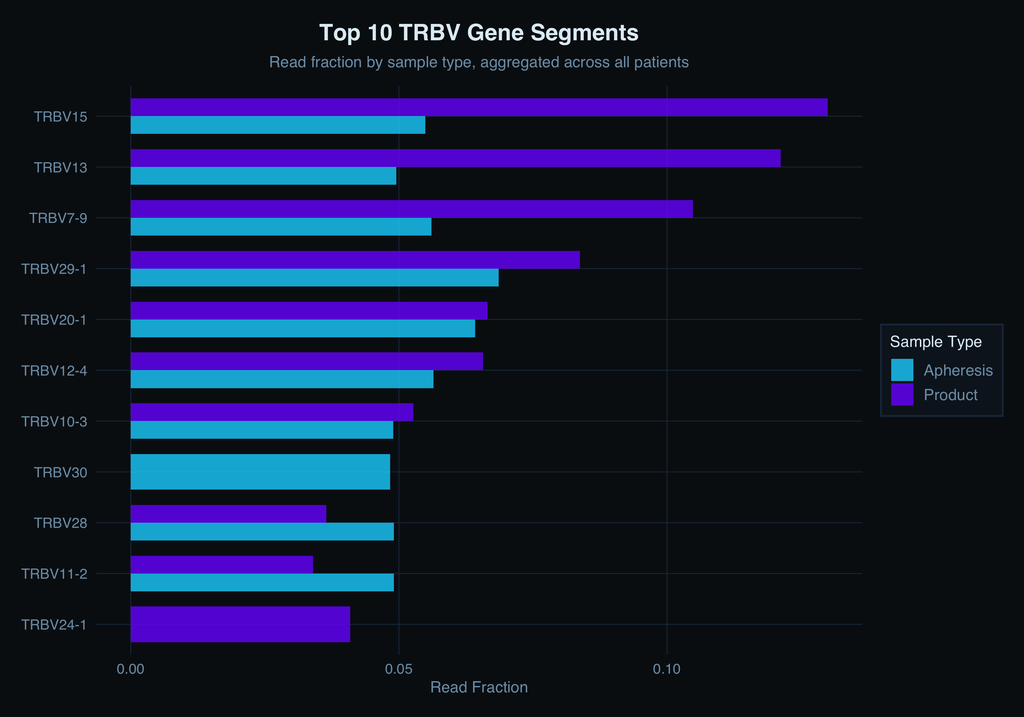

```r
vgene_summary <- tcr_data %>%
  group_by(sample_type, v_gene) %>%
  summarise(total_count = sum(clone_count), .groups = "drop") %>%
  group_by(sample_type) %>%
  mutate(fraction = total_count / sum(total_count)) %>%
  slice_max(fraction, n = 10) %>%
  ungroup()

ggplot(vgene_summary, aes(x = reorder(v_gene, fraction), y = fraction,
                           fill = sample_type)) +
  geom_col(position = "dodge", alpha = 0.8, width = 0.7) +
  coord_flip() +
  scale_fill_manual(values = c("Apheresis" = "#00d4ff", "Product" = "#7b2fff")) +
  labs(x = NULL, y = "Read Fraction", fill = "Sample Type",
       title = "Top 10 TRBV Gene Segments",
       subtitle = "Read fraction by sample type, aggregated across all patients")
```

## Data Quality Notes

> **Synthetic Data Disclaimer:** This dataset is entirely synthetic, generated to demonstrate analytical methods and pipeline architecture. CDR3 sequences are randomly generated and do not correspond to real TCR rearrangements. Clone size distributions follow power-law models calibrated to approximate real repertoire characteristics.

Data quality checks:

- All CDR3 sequences begin with C and end with F (conserved anchors) ✓
- Clone fractions sum to ~1.0 within each sample ✓
- No duplicate clonotype IDs within samples ✓
- All patients have paired Apheresis + Product samples ✓
- TRBV/TRBJ gene names match IMGT nomenclature ✓